# Homework_5v2

Refining Descriptive Stats - ATP PEW

Lenna Garibian  
April 2022

**Setup:** Reading in SPSS (.sav) file titled “atp” and defining two new data frames, title “atp_selected” and “atp_policy” with variable needed for project.

### Project Overview

The objective of this study is to understand what American’s views on democracy, and kind of role Americans want their government to have in the world.

A new Pew Poll (March 2022) suggests that roughly a third of Americans (32%) say that the US is providing about the right amount of support to Ukraine as it fights to hold off the Russian invasion. Another 42% say the US should be providing more support to Ukraine, while only 7% say it is providing too much support, and 19% say they are not sure.

*Note: analysis is a WIP*

### American Perceptions of US Democracy

```r
democracy <- atp_selected %>%

select("US_Democracy") %>%
  group_by(US_Democracy) %>%
summarise(count = n()) %>%
  mutate(percent = count/sum(count) * 100) %>%
    filter(US_Democracy%in% c("Very satisfied", "Somewhat satisfied",
                              "Not too satisfied", "Not at all satisfied")) %>%
  arrange(factor (US_Democracy, levels = c("Very satisfied", "Somewhat satisfied",
                                           "Not too satisfied", "Not at all satisfied")))
  write.csv(democracy,"democracy.csv")
```

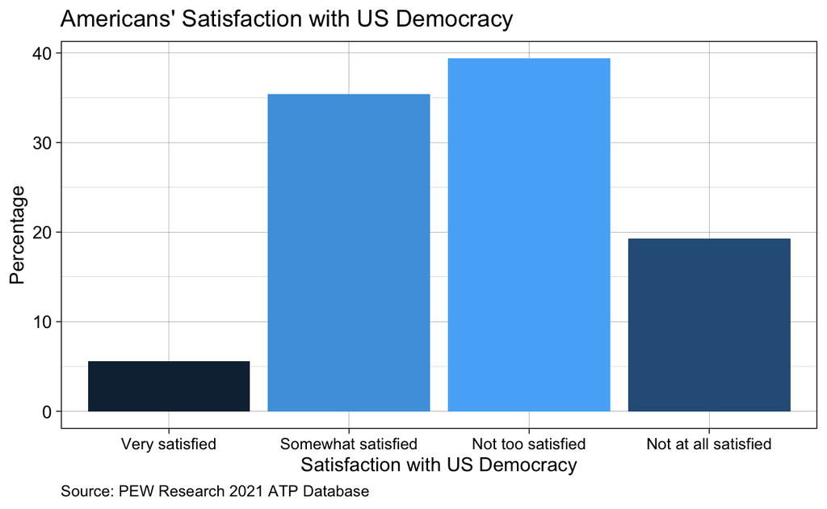

```r
ggplot(democracy, aes(x = US_Democracy, y = percent, fill = percent))+
  geom_bar(stat = "identity")+
theme_bw()+

  labs(x="Satisfaction with US Democracy", y="Percentage",
       title="Americans' Satisfaction with US Democracy",
       caption = "Source: PEW Research 2021 ATP Database")+
      theme_linedraw() +
    theme(axis.text.x = element_text( size = 9),
          axis.text.y = element_text( size = 10),
          text = element_text(size = 11),
         legend.position="none",
          plot.caption = element_text(hjust = 0))
```

### American Democracy as Example for Other Countries

```r
USexample <- atp_selected %>%

select("US_example") %>%
  group_by(US_example) %>%
summarise(count = n()) %>%
  mutate(percent = count/sum(count) * 100) %>%
    filter(US_example %in% c("Is a good example for other countries to follow",
                             "Used to be a good example, but has not been in recent years",
                             "Has never been a good example for other countries to follow"))
```

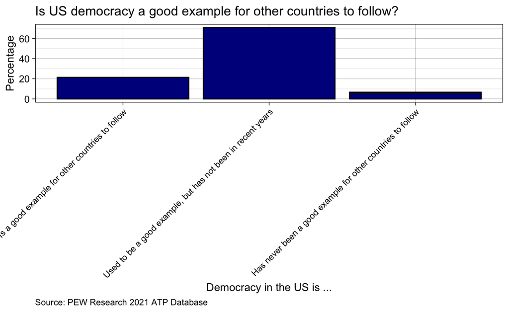

```r
ggplot(USexample, aes(x=US_example, y=percent))+
geom_bar(fill = "blue4", color = "black", stat = "identity", position = position_dodge())+

  labs(x="Democracy in the US is ...", y="Percentage",
       title="Is US democracy a good example for other countries to follow?",
       caption = "Source: PEW Research 2021 ATP Database")+
      theme_linedraw() +
    theme(axis.text.x = element_text( size = 8, angle = 45, hjust = 1),

          axis.text.y = element_text( size = 9),
          text = element_text(size = 10),
          plot.caption = element_text(hjust = 0))
```

### American Democracy as Example for Other Countries - RECODING ERROR -

Want to shorten the answer options, but its not seeing the data anymore

```r
USexampleB <- USexample %>%

select(US_example) %>%
  mutate(US_example = recode(US_example, "Is a good example for other countries to follow" = "Is a good example",
                             "Used to be a good example, but has not been in recent years" = "Used to be a good example",
                             "Has never been a good example for other countries to follow" = "Has never been a good example")) %>%
  group_by(US_example) %>%
summarise(count = n()) %>%
  mutate(percent = count/sum(count) * 100) %>%
    filter(US_example %in% c("Is a good example", "Used to be a good example", "Has never been a good example"))
```

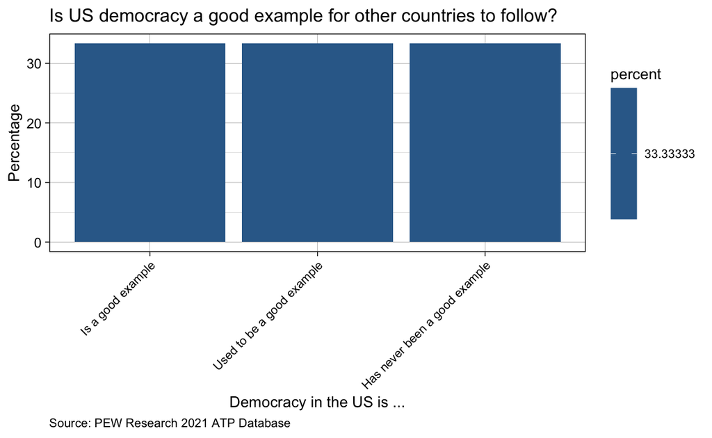

```r
ggplot(USexampleB, aes(x = US_example, y = percent, fill = percent))+
  geom_bar(stat = "identity")+
theme_bw()+

  labs(x="Democracy in the US is ...", y="Percentage",
       title="Is US democracy a good example for other countries to follow?",
       caption = "Source: PEW Research 2021 ATP Database")+
      theme_linedraw() +
    theme(axis.text.x = element_text( size = 8, angle = 45, hjust = 1),

          axis.text.y = element_text( size = 9),
          text = element_text(size = 10),
          plot.caption = element_text(hjust = 0))
```

### US Role in World Leadership, by Political Orientation

```r
USLeadership <- atp_selected %>%

select(c(US_leadership,F_PARTYSUMIDEO))  %>%

  group_by(US_leadership,F_PARTYSUMIDEO) %>%
summarise(count = n()) %>%
  mutate(percent = count/sum(count) * 100) %>%
filter(US_leadership %in%c ("Be the single world leader","Play a shared leadership role",
                            "Not play any leadership role")) %>%
      filter(F_PARTYSUMIDEO %in% c("Liberal Dem/Lean","Conservative Rep/Lean"))
write.csv(USLeadership,"USLeadership.csv")
```

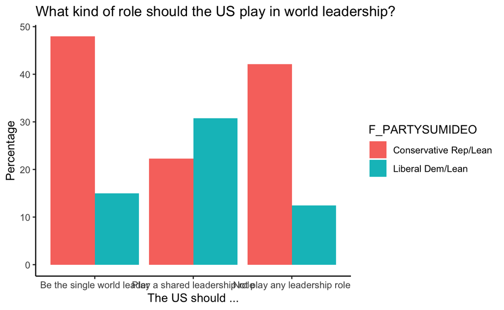

```r
ggplot(USLeadership, aes(x=US_leadership, y=percent, fill=F_PARTYSUMIDEO))+
  geom_bar(stat = "identity", position = position_dodge())+
  labs(x="The US should ...", y="Percentage", title = "What kind of role should the US play in world leadership?")+
  theme_classic()
```

### US Role in World Leadership, by political orientation w/facet wrap -

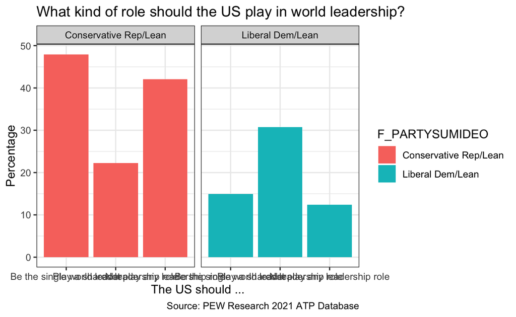

```r
 ggplot(USLeadership, aes(x = US_leadership, y = percent, fill = F_PARTYSUMIDEO))+
  geom_bar(stat = "identity")+
  facet_wrap(~F_PARTYSUMIDEO)+

 theme_bw()+
    labs(x="The US should ...", y="Percentage",
       title="What kind of role should the US play in world leadership?",
       caption = "Source: PEW Research 2021 ATP Database")
```

### Americans’ Confidence in World Leaders

```r
Leadership <- atp_selected %>% select(US_Biden_Confidence,
                                      Chinese_Jinping_Confidence, Russian_Putin_Confidence,
                                      German_Merkel_Confidence, French_Macron_Confidence)

Leadership <- pivot_longer(Leadership, cols=c("US_Biden_Confidence",
                            "Chinese_Jinping_Confidence", "Russian_Putin_Confidence",
                            "German_Merkel_Confidence", "French_Macron_Confidence"),
                           names_to = "World_leaders", values_to = "Level")
```

```r
Leadership <- Leadership %>%

  group_by(`World_leaders`, Level) %>%
  summarise(Freq = n()) %>%

  mutate(percentage = formattable::percent(Freq / sum(Freq)))
head(Leadership)
```

```
# A tibble: 6 × 4
# Groups:   World_leaders [2]
  World_leaders              Level                    Freq percentage
  <chr>                      <fct>                   <int> <formttbl>
1 Chinese_Jinping_Confidence A lot of confidence        29 1.12%
2 Chinese_Jinping_Confidence Some confidence           296 11.40%
3 Chinese_Jinping_Confidence Not too much confidence  1043 40.18%
4 Chinese_Jinping_Confidence No confidence at all     1170 45.07%
5 Chinese_Jinping_Confidence Refused                    58 2.23%
6 French_Macron_Confidence   A lot of confidence       259 9.98%
```

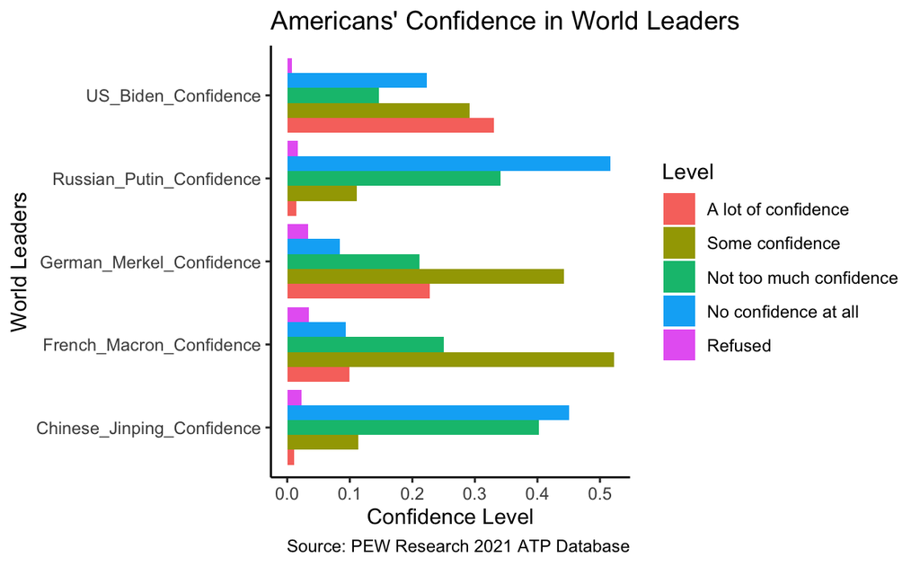

```r
ggplot(Leadership, aes(x=percentage, y=World_leaders, fill=Level))+
geom_bar(stat = "identity", position = position_dodge())+

  labs(x="Confidence Level", y="World Leaders",
       title="Americans' Confidence in World Leaders",
       caption = "Source: PEW Research 2021 ATP Database")+
  theme_classic()
```

### Perceptions Around Collaborating with Other Countries to Solve Problems

```r
US_cooperation_polit_lean <- atp_selected %>%
    rename(Political_Orientation = F_PARTYSUMIDEO) %>%
  select(Intl_Collaboration, Political_Orientation) %>%
  mutate(Intl_Collaboration = recode(Intl_Collaboration, "MANY of the problems facing our country can be solved by working with other countries" = "MANY problems ...", "FEW of the problems facing our country can be solved by working with other countries" = "FEW problems ...")) %>%
  filter(Intl_Collaboration %in% c("MANY problems ...","FEW problems ...")) %>%
  group_by(Intl_Collaboration, Political_Orientation)%>%
summarise(freq = n()) %>%
    mutate(percentage = formattable::percent(freq / sum(freq))) %>%
  filter(Political_Orientation %in% c("Liberal Dem/Lean", "Moderate/Conservative Dem/Lean",
                                      "Moderate/Liberal Rep/Lean", "Conservative Rep/Lean"))
head(US_cooperation_polit_lean)
```

```
# A tibble: 6 × 4
# Groups:   Intl_Collaboration [2]
  Intl_Collaboration Political_Orientation           freq percentage
  <fct>              <fct>                          <int> <formttbl>
1 MANY problems ...  Conservative Rep/Lean            188 13.19%
2 MANY problems ...  Moderate/Liberal Rep/Lean        156 10.95%
3 MANY problems ...  Moderate/Conservative Dem/Lean   483 33.89%
4 MANY problems ...  Liberal Dem/Lean                 543 38.11%
5 FEW problems ...   Conservative Rep/Lean            501 43.95%
6 FEW problems ...   Moderate/Liberal Rep/Lean        234 20.53%
```

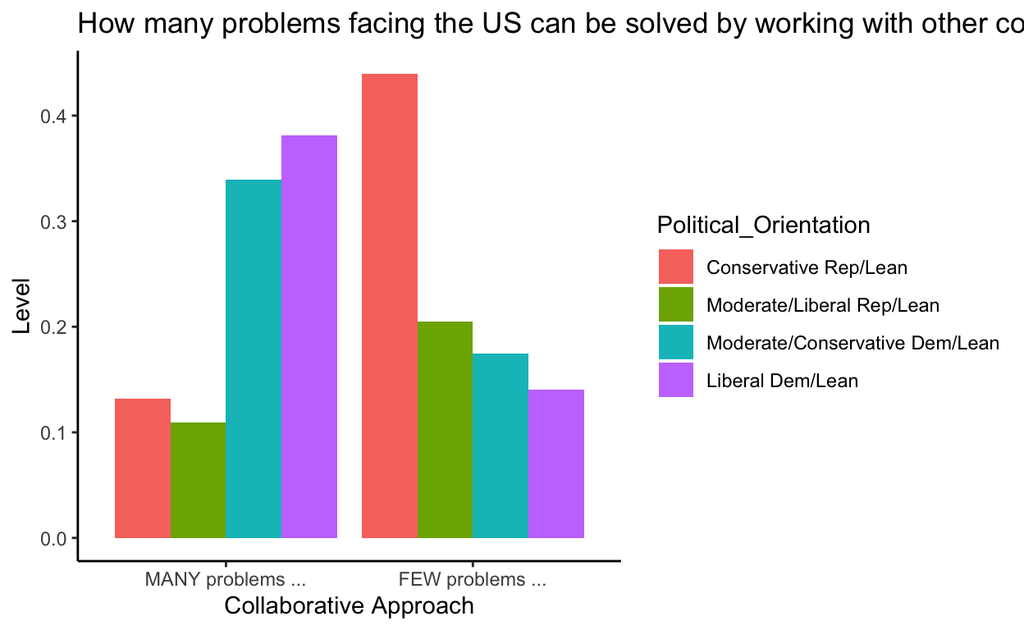

```r
ggplot(US_cooperation_polit_lean, aes(x=Intl_Collaboration, y=percentage, fill=Political_Orientation))+
  geom_bar(stat = "identity", position = position_dodge())+
  labs(x="Collaborative Approach", y="Level", title = "How many problems facing the US can be solved by working with other countries?")+
  theme_classic()
```

### Americans’ Top Policy Priorities - at home and abroad

```r
atp_policy <- atp_policy %>%
select(c(1:21))

atp_policy <- pivot_longer(atp_policy, cols = c(Reduce_WeaponsMD,American_Jobs,Strengthen_UN,
                                    Reduce_USMil_Overseas, Limit_Russia_Power, Promote_Democracy_Overseas,
                                    Reduce_Illegal_Immigr, Limit_China_Power, Maintain_USMil_Advantage,
                                    Global_Climate_Change, Reduce_Trade_Deficit, Promote_Human_Rights,
                                    Reduce_Inf_Diseases,Limit_Iran_Power, Improve_Relations_Allies,
                                    Protect_US_From_Terror, Better_Share_Cost_World_Order,
                                    Aide_Refugees_from_Violence, Reduce_Legal_Immigr_to_US,
                                    Reduce_Legal_Immigr_to_US, Limit_NKorea_Power),
                                    names_to = "Policy-goals", values_to ="Level") %>%

  group_by(`Policy-goals`,`Political_Orientation`, `Level`) %>%
    filter(Political_Orientation %in% c("Liberal Dem/Lean","Conservative Rep/Lean")) %>%
 filter(Level%in% c("Top priority")) %>%
  summarise(freq = n())  %>%
  ungroup() %>%
    mutate(percentage = formattable::percent(freq / sum(freq)))
```

```r
head(atp_policy)
```

```
# A tibble: 6 × 5
  `Policy-goals`               Political_Orien… Level  freq percentage
  <chr>                        <fct>            <fct> <int> <formttbl>
1 Aide_Refugees_from_Violence  Conservative Re… Top …    25 0.40%
2 Aide_Refugees_from_Violence  Liberal Dem/Lean Top …   166 2.65%
3 American_Jobs                Conservative Re… Top …   326 5.20%
4 American_Jobs                Liberal Dem/Lean Top …   199 3.17%
5 Better_Share_Cost_World_Ord… Conservative Re… Top …   218 3.47%
6 Better_Share_Cost_World_Ord… Liberal Dem/Lean Top …    82 1.31%
```

### Americans’ Top Policy Priorities - at home and abroad (new)

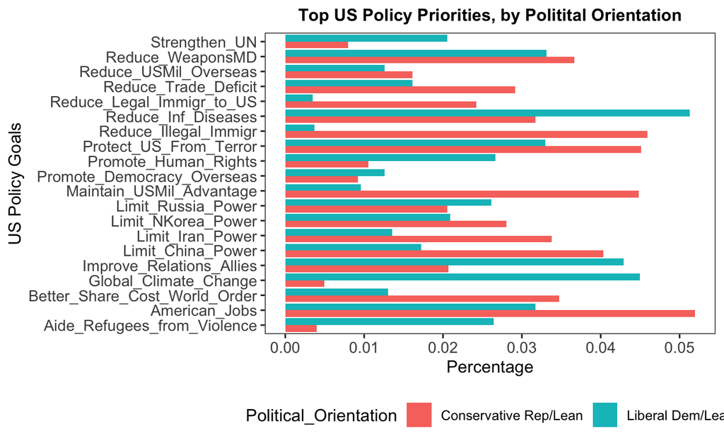

```r
atp_policy %>%

  ggplot(aes(x=`percentage`, y=`Policy-goals`, fill=Political_Orientation)) +
  geom_bar(stat = "identity", position = "dodge")+
 theme_bw()+
    labs(x="Percentage", y="US Policy Goals",
         title = "Top US Policy Priorities, by Politital Orientation")+
  theme(legend.position = "bottom")+
  theme(panel.grid = element_blank(),
            axis.text = element_text(size = 10),
            axis.title = element_text(size = 11),
            plot.title = element_text(size = 11, hjust = 0.5, face = "bold"))
```

### Summary (WIP)

The objective of this study is to understand what American’s views on democracy, and kind of role Americans want their government to have in the world.

A new Pew Poll (March 2022) suggests that roughly a third of Americans (32%) say that the US is providing about the right amount of support to Ukraine as it fights to hold off the Russian invasion. Another 42% say the US should be providing more support to Ukraine, while only 7% say it is providing too much support, and 19% say they are not sure.

New poll also suggests…..you gotta work faster!! :)

**About the data:** Wave 82 American Trends Panel conducted by PEW RESEARCH CENTER via Web, among 2,596 English- and Spanish-speaking Americans, February 1-7, 2021.